# Data Science Capstone Project: Word Prediction

August 16, 2019 - Friday

## Introduction

Objective:

The goal is to build a product specifically a shiny application made using R to highlight the prediction algorithm that is built and to provide a user-friendly interface that can be accessed by others conveniently.

## How was it created?

- Preprocessed the data (removed unnecessary expressions not needed for prediction)
- Stemmed the text corpus
- Created N-grams and Document Frequency Matrices from the corpus
- Tokenized the group of words for better word count
- Created functions to predict next word using the concept of n-gram and backoff modeling

Limitations:

- **If the word or phrase entered in the text box is beyond the scope of the algorithm, it will produce or display "NA"s for all buttons.**
- Words more than three will predict the next word only based on the last two words of the whole phrase or sentence. This is because of the constraints from the n-gram model.

## Shiny Application: How does it work?

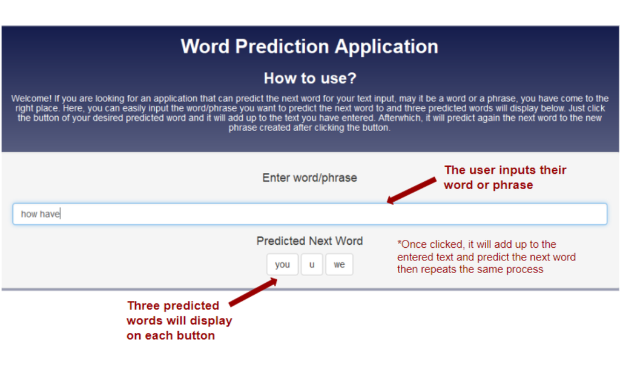

Reminder: The application is subject to limitations mentioned in the previous slide.

## Sources

Shiny Application: https://dajmayo.shinyapps.io/WordPrediction/

Github Repository: https://github.com/dajmayo/Data-Science-Capstone-Project

Dataset: https://d396qusza40orc.cloudfront.net/dsscapstone/dataset/Coursera-SwiftKey.zip